# PCS Documentation

September 22, 2021

# 1 Domain problem formulation

- What is the real-world question? This could be hypothesis-driven or discovery-based.
- Why is this question interesting and important? What are the implications of better understanding this data?
- Is there any prior work or background information related to this question? Describe the premise and put your questions and analysis in the domain context.
- Briefly describe how this question can be answered in the context of a model or analysis.
- Outline the rest of the report/analysis.

# 2 Data

- What is the data under investigation? Provide a brief overview/description of the data.
- How is this data relevant to the problem of interest? In other words, make the link between the data and the domain problem.

## 2.1 Data Collection

- How was the data collected or generated (including details on the experimental design)? Be as transparent as possible so that conclusions made from this data are not misinterpreted down the road.
- Describe what the data represents in reality, i.e., make the link between the data and reality. Also be sure to describe ways in which the data cannot model reality.
- Where is the data stored, and how can it be accessed by others (if applicable)?

## 2.2 Data splitting

- Split the data into a training, validation, and test set.
- Decide on the proportion of data in each split.
- Decide on the “how” to split the data (e.g., random sampling, stratified sampling, etc.), and explain why this is a reasonable way to split the data.
- Provide summary statistics and/or figures of the three data sets to illustrate how similar (or different) they are.

```r
# TODO: pick more interesting datasets
X <- iris %>% dplyr::select(-Species)
y <- iris$Species
data_df <- dplyr::bind_cols(.y = y, X)
splits <- rsample::initial_split(data_df)
train_df <- rsample::training(splits)
valid_df <- rsample::testing(splits)
Xtrain <- X  # placeholders for now
Xvalid <- X
Xtest <- X
ytrain <- y
yvalid <- y
ytest <- y
```

## 2.3 Data Cleaning and Preprocessing

- What steps were taken to clean the data? More importantly, why was the data cleaned in this way?
- Discuss all inconsistencies, problems, oddities in the data (e.g., missing data, errors in data, outliers, etc.).
- Record your preprocessing steps in a way such that if someone else were to reproduce your analysis, they could easily replicate and understand your steps.
- It can be helpful to include relevant plots that explain/justify the choices that were made when cleaning the data.
- If more than one preprocessing pipeline is reasonable, examine the impacts of these alternative preprocessing pipelines on the final data results.
- Again, be as transparent as possible. This allows others to make their own educated decisions on how best to preprocess the data.

## 2.4 Data Exploration

- The main goal of this section is to give the reader a feel for what the data “looks like” at a basic level.
- Provide plots that summarize the data and perhaps even plots that convey some smaller findings which ultimately motivate the main findings.
- Provide additional plots representing remaining oddities after pre-processing if applicable.
- Add summary statistics in accompanying tables (or in figures) for quick comparisons.

### 2.4.1 Data Overview

```
#> Number of samples: 150
#> Number of features: 4
#> Number of NAs in training y: 0
#> Number of NAs in training X: 0
#> Number of columns in training X with NAs: 0
#> Number of constant columns in training X: 0
```

#### Summary Tables

```r
data_types(Xtrain = Xtrain, ytrain = ytrain)
```

|  | Factor | Numeric |
| --- | --- | --- |
| X | 0 | 4 |
| y | 1 | 0 |

```r
dt_ls <- data_summary(Xtrain = Xtrain, ytrain = ytrain, digits = 2, sigfig = F)
for (dt_name in names(dt_ls)) {
  subchunkify(dt_ls[[dt_name]], i = chunk_idx, other_args = "results='asis'")
  chunk_idx <- chunk_idx + 1
}
```

| Variable Name | # Missing | % Missing | Ordered Factor | # Unique Factors | Top Factor Counts |
| --- | --- | --- | --- | --- | --- |
| .y | 0 | 0.00 | False | 3 | set: 50, ver: 50, vir: 50 |

| Variable Name | # Missing | % Missing | Mean | SD | Minimum | Q1 | Median | Q3 | Maximum | Histogram |
| --- | --- | --- | --- | --- | --- | --- | --- | --- | --- | --- |
| Sepal.Length | 0 | 0.00 | 5.84 | 0.83 | 4.30 | 5.10 | 5.80 | 6.40 | 7.90 | ▆▇▇▅▂ |
| Sepal.Width | 0 | 0.00 | 3.06 | 0.44 | 2.00 | 2.80 | 3.00 | 3.30 | 4.40 | ▁▆▇▂▁ |
| Petal.Length | 0 | 0.00 | 3.76 | 1.77 | 1.00 | 1.60 | 4.35 | 5.10 | 6.90 | ▇▁▆▇▂ |
| Petal.Width | 0 | 0.00 | 1.20 | 0.76 | 0.10 | 0.30 | 1.30 | 1.80 | 2.50 | ▇▁▇▅▃ |

#### X distribution

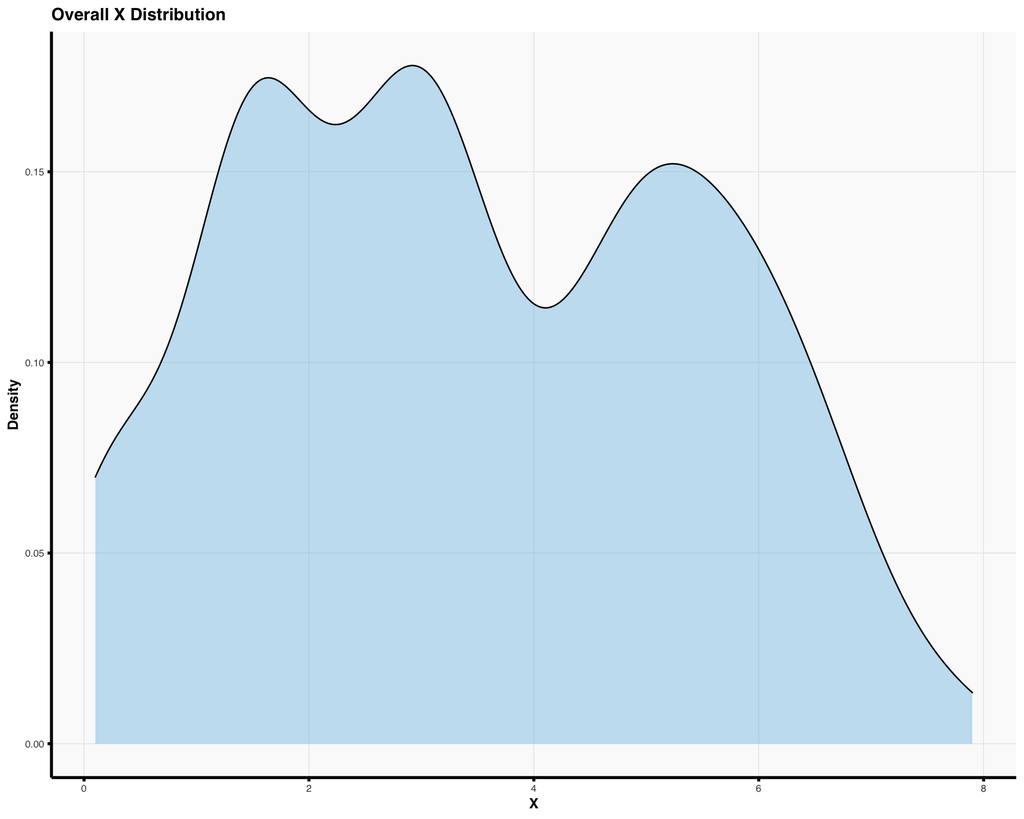

```r
# plot X distribution
plot_X_distribution(Xtrain, "density")
```

#### Y distribution

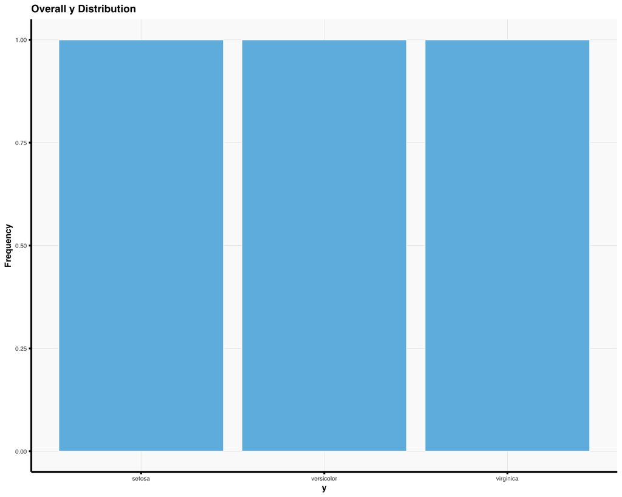

```r
# plot y distribution
plot_y_distribution(ytrain, "bar")
```

#### Feature Correlation

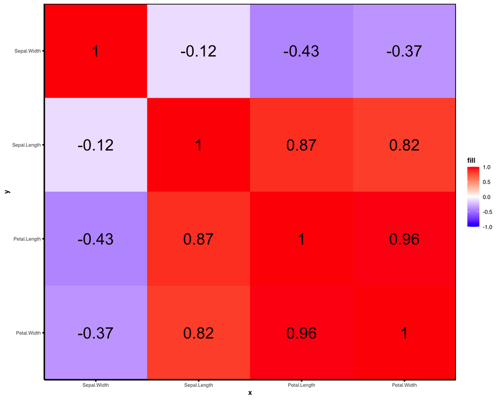

```r
# correlation heatmap
plotCorHeatmap(X = Xtrain, cor.type = "pearson", clust = TRUE, text.size = 8)
```

#### Feature Pair Plots

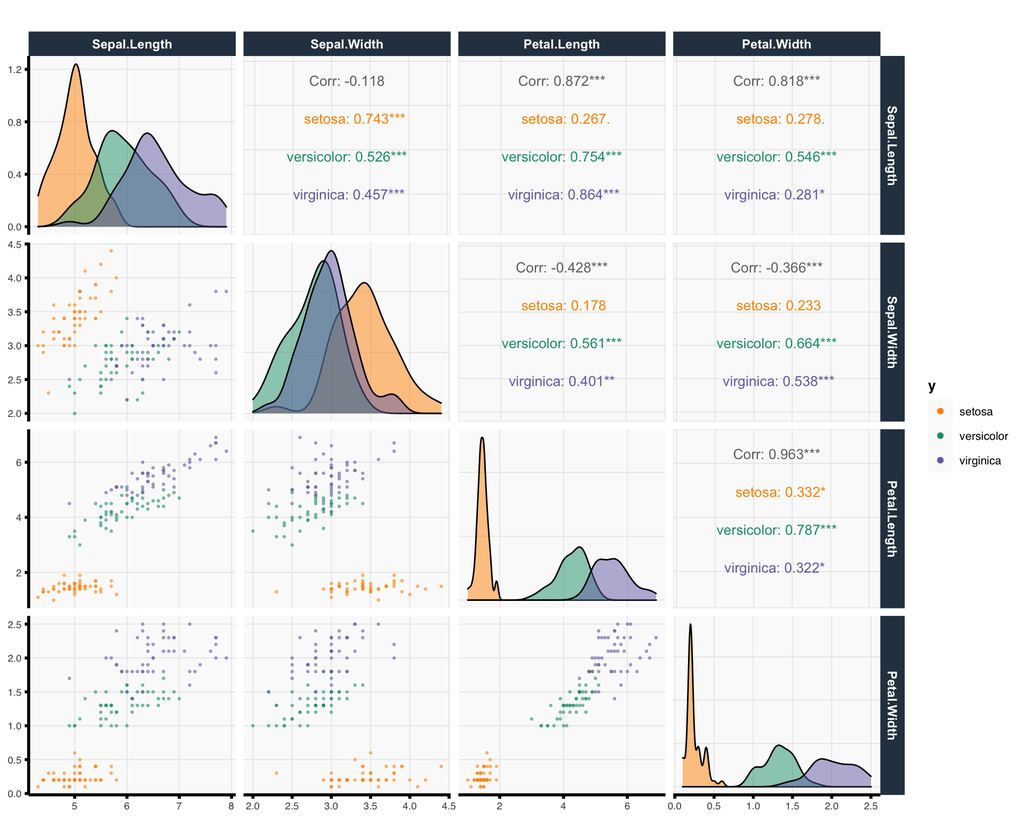

```r
# pair plots
col_ids <- 1:min(ncol(Xtrain), 6)
plotPairs(data = Xtrain, columns = col_ids,
          color = ytrain, color.label = "y")
```

#### PCA Plots

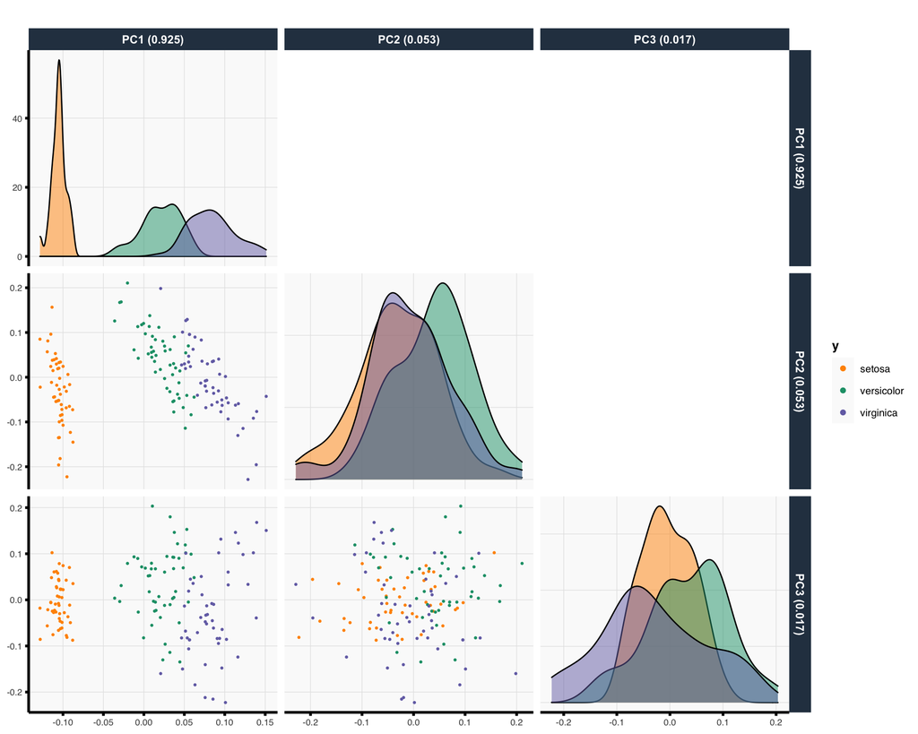

```r
# dimension reduction plots
plotPCA(X = Xtrain, npcs = 3, color = ytrain, color.label = "y",
        center = T, scale = FALSE)$plot
```

For inspiration: [Shiny App](https://tiffanymtang.shinyapps.io/ShinyEDA/)

# 3 Prediction Modeling

- Discuss the prediction methods under consideration, and explain why these methods were chosen.
- Discuss the accuracy metrics under consideration, and explain why these metrics were chosen.
- Note: there should be multiple methods and metrics under consideration to paint a more holistic picture of the data. At least one method should be a baseline, common approach that may not be optimal for the problem setting, but serves as a helpful comparison.

## 3.1 Prediction check

- Carry out the prediction pipeline, outlined above.
  - Fit prediction methods on training data.
  - Evaluate prediction methods on validation data.
  - Compare results, and filter out poor models.

```r
# TODO: add code for tuning parameters
mod_recipe <- recipes::recipe(.y ~., data = splits)

# for classification
rf_mod <- parsnip::rand_forest() %>%
  # parsnip::set_args(metric = tune::tune()) %>%
  parsnip::set_engine("ranger", importance = "impurity") %>%
  parsnip::set_mode("classification")

svm_model <- parsnip::svm_rbf() %>%
  parsnip::set_engine("kernlab") %>%
  parsnip::set_mode("classification")

log_model <- parsnip::logistic_reg() %>%
  parsnip::set_engine("glmnet") %>%
  parsnip::set_mode("classification")

model_list <- list(RF = rf_mod, SVM = svm_model, Logistic = log_model)
model_fits <- list()
model_preds <- list()
model_errs <- list()
for (model_name in names(model_list)) {
  mod <- model_list[[model_name]]
  mod_fit <- workflows::workflow() %>%
    workflows::add_recipe(mod_recipe) %>%
    workflows::add_model(mod) %>%
    tune::last_fit(splits)
  model_fits[[model_name]] <- mod_fit
  model_preds[[model_name]] <- mod_fit %>%
    tune::collect_predictions()
  model_errs[[model_name]] <- mod_fit %>%
    tune::collect_metrics()
}
model_preds <- dplyr::bind_rows(model_preds, .id = "model")
model_errs <- dplyr::bind_rows(model_errs, .id = "model")
```

[output not shown]

## 3.2 Stability check

- Taking the prediction methods that pass the prediction check, perform stability analysis.
  - Specify and justify the appropriate data perturbation(s).
  - Re-fit the prediction methods on these perturbed data sets.
  - Evaluate prediction methods on validation data.
  - Assess stability across the data perturbations as well as across the various methods.
  - Filter out poor models where necessary and interpret stability results.

## 3.3 Interpretability

- For the models that pass the prediction and stability checks,
  - Extract the important features in the predictive models that are stable across both data and model perturbations. Determining the importance of a feature can be method dependent.

# 4 Main Results

- Interpret and summarize the prediction and stability results.
- Evaluate pipeline on test data.
- Summarize test set prediction and/or interpretability results.

# 5 Post hoc analysis

- Move beyond the global prediction accuracy metrics and dive deeper into individual-level predictions for the validation and/or test set, i.e., provide a more “local” analysis.
  - Examine any points that had poor predictions.
  - Examine differences between prediction methods.

# 6 Conclusions

- Reiterate main findings, note any caveats, and clearly translate findings/analysis back to the domain problem context.